# An Exploration of Macroinvertebrate Live Body Mass

Emily Wapman

5/5/2021

### Abstract:

The body size of an organism influences its ecological niche and many environmental processes. The live body mass of arthropods can be difficult and tedious to calculate, so linear regressions are useful tools for predicting this metric. In this project, I used data on the length, width, and geographic region of origin of various arthropod orders from a 2018 study by Sohlström et al. I ran statistical tests to analyze if there is a difference in live body mass across the different orders and to determine which variables in the data set are the best predictors of live body mass in a linear regression. I found that the smallest insect order used in the analysis, Araneae, is significantly smaller than the two largest insect orders used in the analysis, Dictyoptera and Orthoptera, and that the best predictor of live body mass uses body length and body width as interaction terms and order and geographic region as covariates. These results emphasize the importance of body size measurements in predicting live body mass and allows for speculation about the ecological role of the organisms with significantly different body sizes. Further studies should focus on this link between body size and ecological role and add additional body size measurements to improve regression accuracy.

### Introduction:

Organism body size is a central driver of ecological processes at both the individual and ecosystem levels. It impacts physiological processes and behaviors at the organismal level, which extend beyond the individual level to influence species interactions and ecosystem processes. For example, a 1968 study by D. Reichle demonstrated how differences in metabolic rate among organisms depends on body mass, with per capita metabolic rate increasing with body size and mass-specific metabolic rate, or the ratio of metabolic rate to body mass, decreasing with larger body mass (Reichle 1968) (Sohlström 2018). Foraging ranges tend to increase with body size as well (Sohlström 2018). Because of the significant role of body size in shaping ecosystem processes, live body mass data is often very desirable for researchers studying ecosystem health.

Obtaining large sample sizes of live arthropod body mass can be challenging and time consuming. This study by Sohlström et al. collected body measurement data of various arthropod taxa to find the most accurate linear regression predicting live body mass based on body length, width, taxonomic group, and geographic region. This data was published in the journal Ecology and Evolution. In total, the dataset has 300 observations and 8 variables with a 9th column describing the analysis. This study found that the prediction accuracy of the regression was best when body width was used in addition to body length as a predictor of live body mass. Additionally, regression models were less accurate predictors when regression parameters came from different geographic regions due to the differences in body size that occur based on latitude (Sohlström 2018). A study on the body size of ectotherms from different geographic regions showed that, contrary to trends observed for endotherms, ectotherms tend to decrease in size as temperature decreases due to the shorter length of the seasons, causing a shorter growth period (Mousseau 1996).

I am using this dataset by Sohlström et al. to practice the statistical analysis techniques I have developed in EEMB 146. First, I plan to analyze live body mass across the different arthropod orders to see if any of the orders have significantly larger or smaller mean body masses than the others. I expect that there will be a significant difference in live body mass between at least one pair of taxa because the study includes a large variety of taxa from different regions with a uniquely different morphological and physiological structure and ecological niche, all of which influence body mass. Additionally, I will analyze what variables: body length, body width, geographic region, or order, are the best predictors of live body mass. I expect that body length will be the best predictor individually but that the best linear model will include all predictors with body length and body width as interaction terms.

### Exploratory Data Analysis

The histogram of live body mass shows that the data is right skewed (Figure 1), so I log transformed the data to achieve normality and used this transformed data for the exploratory analysis. Figure 2 shows that there does seem to be a positive trend in the relationship between body length and the log live body mass and between body width and the log live body mass, so I expect that these will be strong predictors for my second test evaluating various general linear models. Based on figure 3, I expect that geographic region will be a weak predictor of live body mass. There is a slightly higher mean log live body mass for organisms from temperature regions. Although this difference is small, the study of body size and temperature indicates that geographic region may still be a valuable predictor (Mousseau 1996). I expect order to be a weak predictor of live body mass as well. Figure 5 shows that there are differences in the mean log live body mass across the different orders. However, similarly to geographic region, these differences are small and the boxplots overlap. Because figure 5 indicates slight differences in the means log live body mass of the different orders, I expect that there will be a statistically significant difference in body size between at least one pair of arthropod orders.

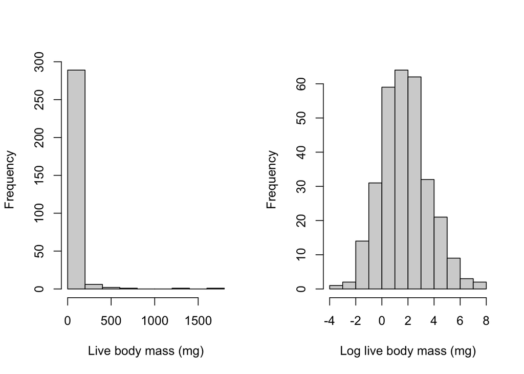

**Figure 1: Distribution of response variable, live body mass.** This shows that distribution of live body mass has a strong right skew (left), but appears normal after a log transformation (right)

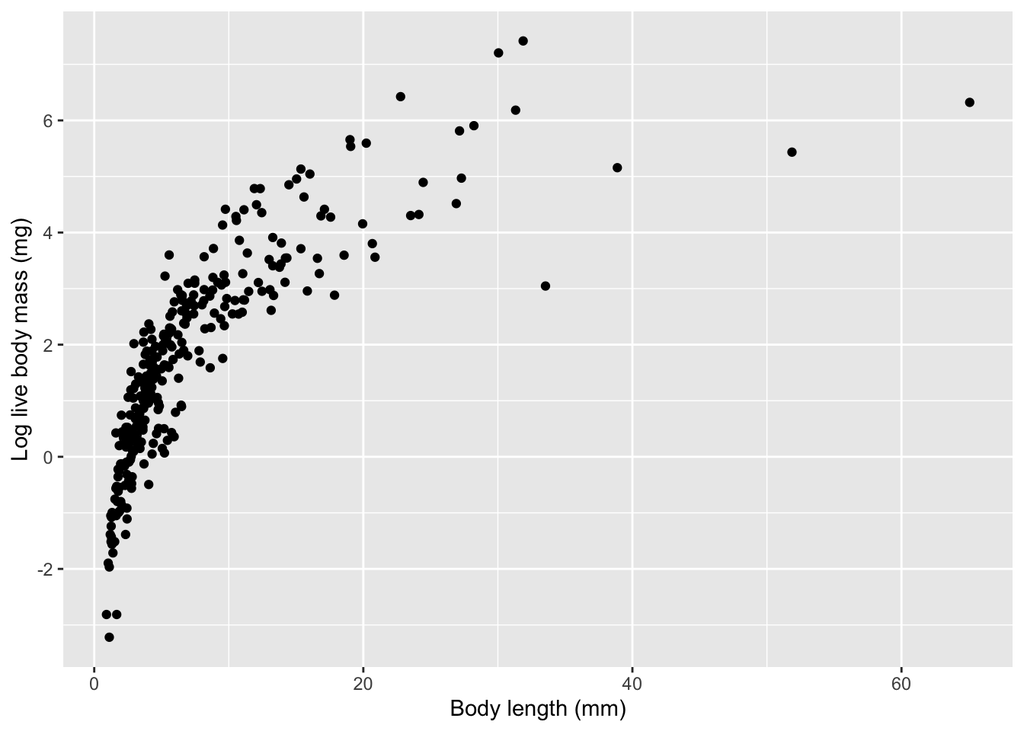

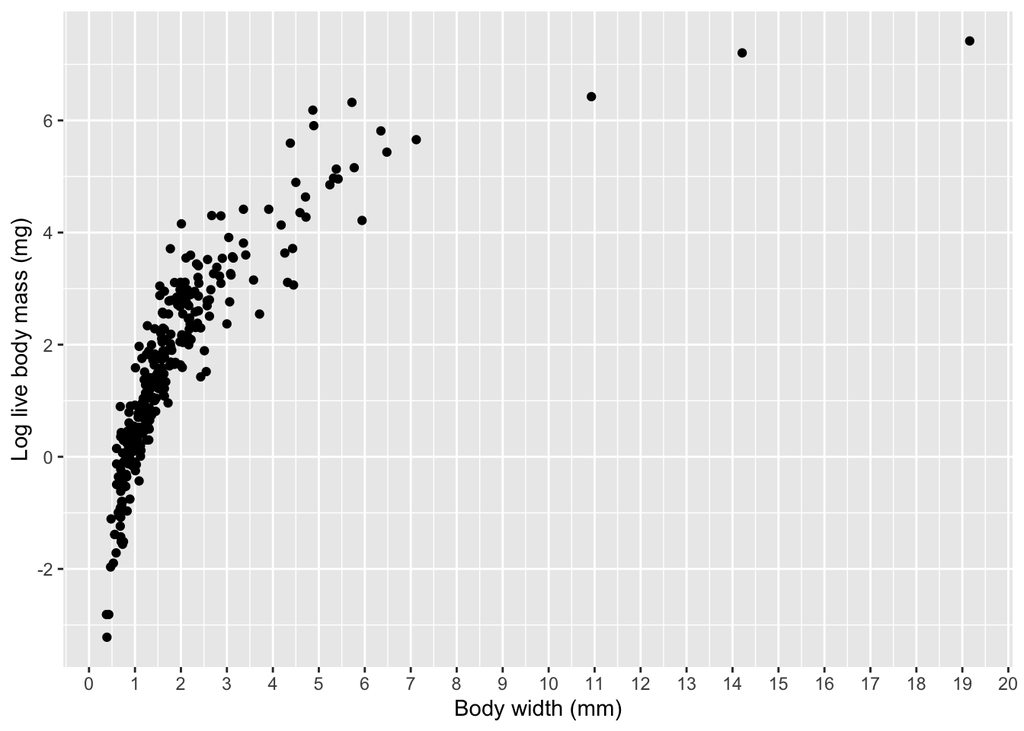

**Figure 2: Relationship between body length (Top) and body width (bottom) to the log live body mass.** Both graphs show an increasing trend between body length and live body mass and body width and live body mass.

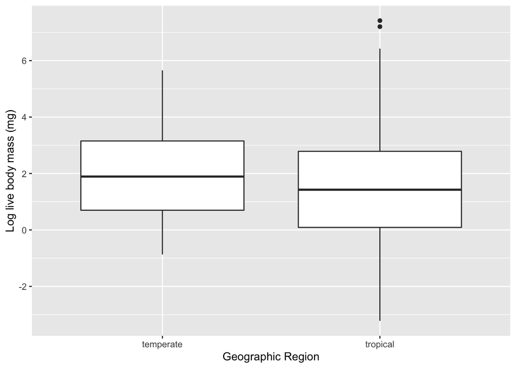

**Figure 3: Effect of geographic region on log live body mass.** This box plot shows the live body mass of macroinvertebrates collected in temperate versus tropical regions. The mean for temperate regions have a slightly higher mean, but the two categories lack distinct differences. The tropical boxplot shows that two outliers are present

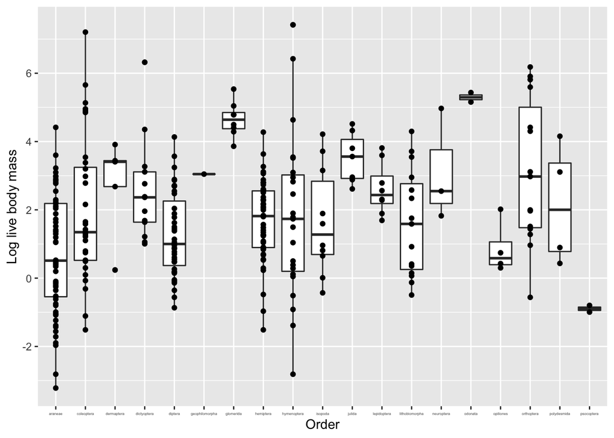

**Figure 4: Boxplot of Order by Log live body mass** This boxplot shows the distribution of the log live body mass for each order as well as the number of observations found in each order (1 observation = 1 black dot). The orders with at least 10 observations were selected for further analysis. Three ouliers are present in this boxplot

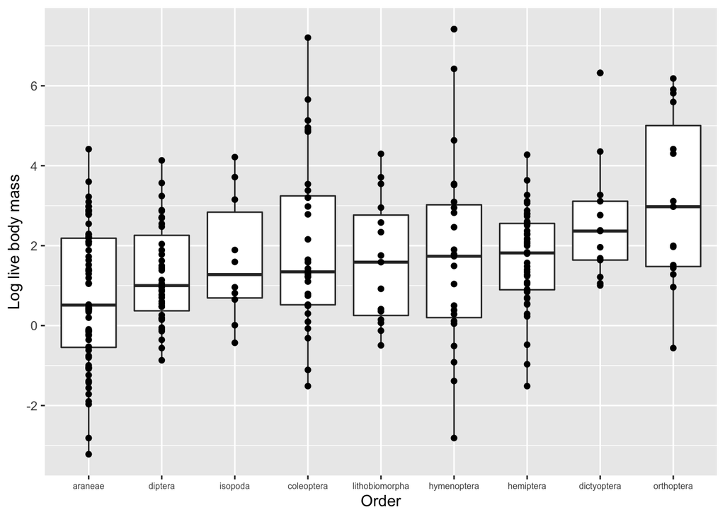

**Figure 5: Subsetted boxplot of Order by Log live body mass** Shows the orders selected for final analysis. Two outliers are present in the subsetted data.

### Statistical Methods

##### Does live bodymass vary with macroinvertebrate order?

**Test 1:**

I ran a Kruskal Test to test if the mean log live body mass of any of the groups is different from the others. A Kruskal Test is a non parametric test used in place of an ANOVA when the data do not meet the required assumptions for a parametric test. The Kruskal Test uses ranks for the analysis. For an ANOVA to be possible, the data must be randomly sampled, the response variable must be normally distributed, and there must be homogeneity of variance.

For this data, random sampling can be assumed from the experimental design. Figure 1 and a Shapiro-Wilk test and qqPlot showed that the response variable (live body mass) is normal after a log transformation (see Appendix). The data does not, however, follow the assumption of homogeneity of variance even after testing other transformations (see Appendix), so the use of the non parametric test was necessary. After running a Kruskal test, I used a Dunn test to run nonparametric pairwise comparisons.

**Hypotheses**

$H_0:$ The mean ranks of the groups are all the same.

$H_A:$ At least one of the group’s mean ranks of the is not equal to at least one other.

I expect that at least one of the arthropod orders will have significantly different mean log live body mass rank from the others.

##### What variables are the best predictors of live body mass?

**Test 2:** My data did not meet the assumptions of normality and linearity required to run standard linear models (see Appendix), so I used general linear models to test which combination of predictors: body length, body width, order, and geographic region, create the best general linear model predicting live body mass. I tested models using each of the predictors independently, the interaction between body length and body width, and then tested different combinations of the predictors. The only assumptions that must be met for general linear models are that the Y variable should be independent and distributed like the random component. In this case, the Y data is independent and fits a Poisson distribution. The Poisson family requires integer data, however, so I rounded the live body mass values to the nearest whole number for this analysis.

**Hypothesis**

$H_0$: The general linear model using all explanatory variables with length and width as interaction terms is not the best predictor of live body mass.

$H_A$: The general linear model using all the explanatory variables with length and width as interaction terms will be the best predictor of live body mass.

### Results

##### Does live bodymass vary with macroinvertebrate order?

After running the Kruskal Test, I used a Dunn test to run pairwise multiple comparisons. Overall, the live body mass was compared between 36 different order pairs. There is a significant difference between Araneae, the smallest order, and the two largest orders, Dictyoptera (p = 0.03) and Orthoptera (p = 0.0028), so we are able to reject the null hypothesis that the mean ranks of the groups are all the same (Table 1).

**Table 1: Dunn Test Results** Only two pairwise comparisons were significant after running the posthoc analysis of the Kruskal Test. The live body mass of the smallest order, Araneae, is significantly different from the two largest orders, Dictyoptera and Orthoptera.

| Comparison | Z | P-value: unadjusted | P-value: adjusted |
| --- | --- | --- | --- |
| Araneae - Dictyoptera | -3.31 | 9.17e-04 | 0.0330 |
| Araneae-Orthoptera | -3.95 | 7.78e-05 | 0.0028 |

##### What variables are the best predictors of live body mass?

I ran 9 general linear models to test which variables and combinations of variables are the best predictors of live body mass. Stronger predictors have lower AIC and BIC values. Body width (AIC = 12465.65, BIC = 12472.96) is a stronger predictor than body length (AIC = 21391.51, BIC = 21398.92) and the model is even stronger when body length and body mass are used as interaction terms (AIC = 2877.34, BIC = 2891.95) instead of as covariates (AIC = 7192.92, BIC = 7203.87). Order (AIC = 28697.96, BIC = 28768.33) and geographic region (AIC = 40232.32, BIC = 40239.73) are both weaker predictors than body length and body width with geographic region being the weaker predictor. The most successful model uses order, geography, and body width and body length as interaction terms (AIC = 1635.01, BIC = 1711.72), so we reject the null hypothesis (Table 2).

**Table 2: General Linear Models** Table shows the degrees of freedom, AIC, and BIC values for the general linear models testing the best predictor of live body mass. The model using order, geographic region and body length and body width as interaction terms is the best model because it has the lowest AIC and BIC values.

|  | df | AIC | BIC |
| --- | --- | --- | --- |
| live body mass ~ body length | 2 | 21391.51 | 21398.92 |
| live body mass ~ body width | 2 | 12465.65 | 12472.96 |
| live body mass ~ length * width | 4 | 2877.34 | 2891.95 |
| live body mass ~ length + width | 3 | 7192.92 | 7203.87 |
| live body mass ~ order | 19 | 28697.96 | 28768.33 |
| live body mass ~ geographic region | 2 | 40232.32 | 40239.73 |
| live body mass ~ body length * body width + order | 20 | 1688.81 | 1761.86 |
| live body mass ~ body length * body width + geography | 5 | 2807.78 | 2826.04 |
| live body mass ~ body length * body width + order + geography | 21 | 1635.01 | 1711.72 |

### Discussion

##### **Does live bodymass vary with macroinvertebrate order?**

The Kruskal Wallace test and post hoc analysis with a Dunn’s test showed that the order Araneae, the smallest order included in the analysis, has a significantly smaller live body mass than the orders Dictyoptera and Orthoptera, the largest orders included in this analysis. This result supports my initial hypothesis that at least one of the orders would be different from at least one other. I expected this result because my preliminary analysis showed some variation between the mean log live body mass, so I expected that there was likely a difference between at least the largest and smallest orders (Figure 5).

As shown in figure 5, all the tested insect orders have relatively similar live body masses, so it makes sense that only the two largest orders were detected to be significantly different. This result allows us to speculate the reason behind these differences in live body mass based on ecological niche. The order Araneae is comprised of web building spiders (Coddington and Levi 1991). A smaller body size may be necessary for these organisms to be mobile and light enough to weave and live on delicate webs. Orthoptera may be the largest order because organisms in this order commonly have acoustic abilities, and larger Orthopterans are able to produce louder sounds (Robinson and Hall 2002). A 2011 study determined that larger body size in Madagascar hissing cockroaches was correlated with more aggressive behavior (Logue et al. 2011). Madagascar hissing cockroaches are part of a suborder of Dictyoptera, known as Blattodea, so the larger size of the order Dictyoptera may be beneficial for both inter and intraspecific competition. Future experiments should analyze the relationship between the body size and arthropod behavior of each order more closely.

##### **What variables are the best predictors of live body mass?**

Analysis of a variety of general linear models (Table 2) showed that my hypothesis regarding what factors are the best predictors of live body mass was correct. There is an interaction between the body length and body width of an organism, however I was incorrect to assume that body length would be a stronger predictor than body width. Order and geographic region of origin were also important predictors to add in the model. Although they are weak by themselves, the lower AIC and BIC values show that each order has a relatively distinct live body mass and that geographic region does slightly influence live body mass.

These results are similar to the findings discussed by Söhlstrom et. al. This study emphasized the importance of using multiple body size parameters to create an accurate predictive model of live body mass. However, this paper did not emphasize the importance of the interaction between body length and body width that was observed in my analysis and placed a greater emphasis on the strength of body length as the main parameter. The AIC and BIC values for models using using length and width as interaction terms show that these models are almost twice as accurate than when these terms are just used as covariates. Sohlström et al. also showed that order and geographic region influence predictions of live body mass due to the effects of phylogenetic history and environmental variation on body size (Sohlström 2018), although it is clear from this study and from this analysis that these predictors are not as strong as body metric predictors. A future study could try adding height as a predictor of live body mass to see if this creates an even more accurate model.

### References

##### **Articles**

Coddington, J. A., and H.W. Levi. 1991. Systematics and Evolution of Spiders (Araneae). Annual Review of Ecology and Systematics 22:565-592.

Logue, D.M., A.D. Takahashi, W.H.Cade. 2011. Aggressiveness and Size: A Model and Two Tests. The American Naturalist 177:202-210.

Mousseau,T.A. 1997. Ectotherms Follow the Converse to Bergmann’s Rule. Society for the Study of Evolution. 51:630-632.

Reichle, D. 1968. Relation of Body Size to Food Intake, Oxygen Consumption, and Trace Element Metabolism in Forest Floor Arthropods. Ecology 49:538-542.

Sohlström, E.H., L. Marian, A.D. Barnes, N.F. Haneda, S. Scheu, B.C. Rall, U. Brose, M. Jochum. 2018. Applying generalized allometric regressions to predict live body mass of tropical and temperate arthropods. Ecology and Evolution 8:12737-12749.

##### **Packages**

John Fox and Sanford Weisberg (2019). An {R} Companion to Applied Regression, Third Edition. Thousand Oaks CA: Sage. URL: https://socialsciences.mcmaster.ca/jfox/Books/Companion/

Torsten Hothorn, Frank Bretz and Peter Westfall (2008). Simultaneous Inference in General Parametric Models. Biometrical Journal 50(3), 346–363.

Ogle, D.H., P. Wheeler, and A. Dinno. 2021. FSA: Fisheries Stock Analysis. R package version 0.8.32, https://github.com/droglenc/FSA.

H. Wickham. ggplot2: Elegant Graphics for Data Analysis. Springer-Verlag New York, 2016.

Wickham et al., (2019). Welcome to the tidyverse. Journal of Open Source Software, 4(43), 1686, https://doi.org/10.21105/joss.01686

Hadley Wickham and Jim Hester (2020). readr: Read Rectangular Text Data. R package version 1.4.0. https://CRAN.R-project.org/package=readr

Revelle, W. (2020) psych: Procedures for Personality and Psychological Research, Northwestern University, Evanston, Illinois, USA, https://CRAN.R-project.org/package=psych Version = 2.1.3,.

Yihui Xie (2020). knitr: A General-Purpose Package for Dynamic Report Generation in R. R package version 1.29.

### Appendix

#### Exploratory Data Analysis

```r
# General Data Checking
#head(bugs)
#summary(bugs)
bugs$Order <- as.factor(bugs$Order) # Convert to factor
levels(bugs$Order)
```

```
##  [1] "araneae"        "coleoptera"     "dermaptera"     "dictyoptera"
##  [5] "diptera"        "geophilomorpha" "glomerida"      "hemiptera"
##  [9] "hymenoptera"    "isopoda"        "julida"         "lepidoptera"
## [13] "lithobiomorpha" "neuroptera"     "odonata"        "opiliones"
## [17] "orthoptera"     "polydesmida"    "psocoptera"
```

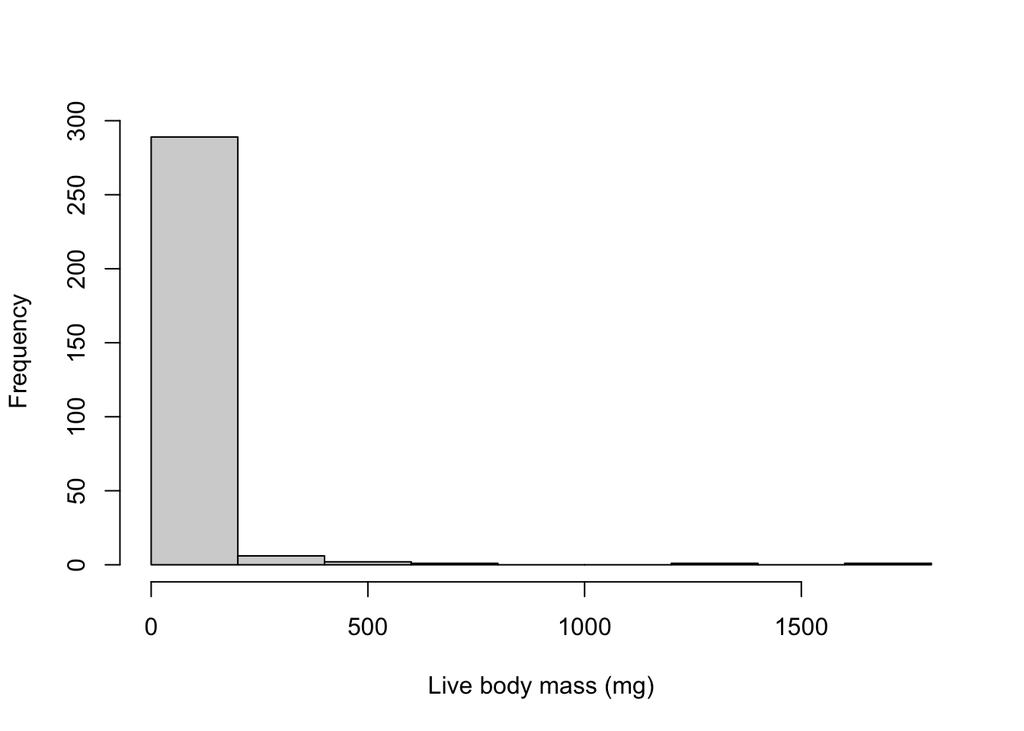

```r
bugs$Body.width..mm.<- as.numeric(bugs$Body.width..mm.) # Convert to numeric

# Check normality of y
hist(bugs$Live.body.mass..mg., main = "", xlab = "Live body mass (mg)")
```

```r
# Run Shapiro Wilk test for y variable
shapiro.test(bugs$Live.body.mass..mg.) # Not normal
```

```
##
##  Shapiro-Wilk normality test
##
## data:  bugs$Live.body.mass..mg.
## W = 0.24247, p-value < 2.2e-16
```

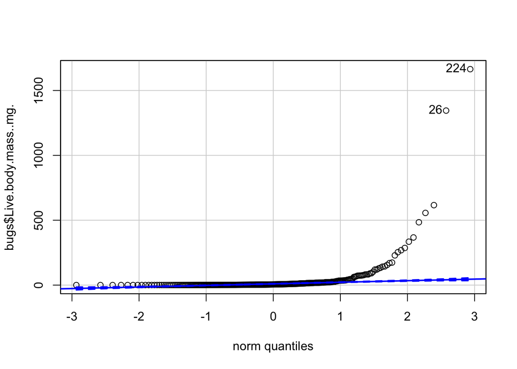

```
## [1] 224  26
```

```r
# Make qqPlot
qqPlot(bugs$Live.body.mass..mg.) # Looks not normal
```

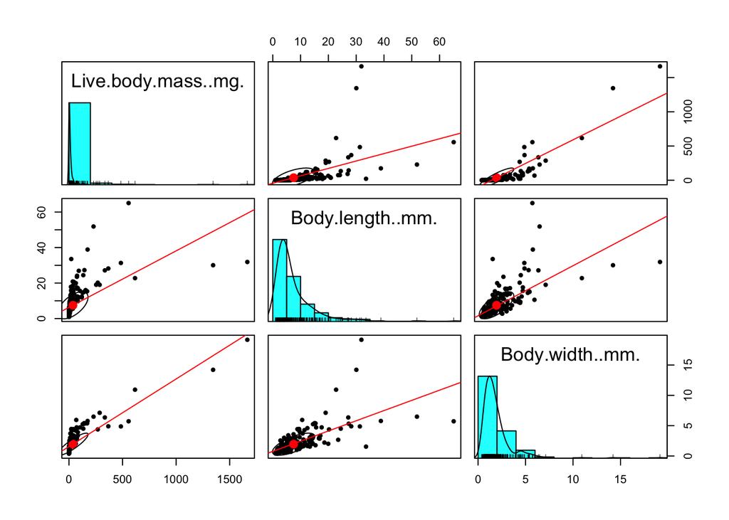

```r
# More numeric investigation
plot.bugs <- data.frame(bugs[, 5:7])
pairs.panels(plot.bugs, density = TRUE, cor = FALSE, lm = TRUE)
```

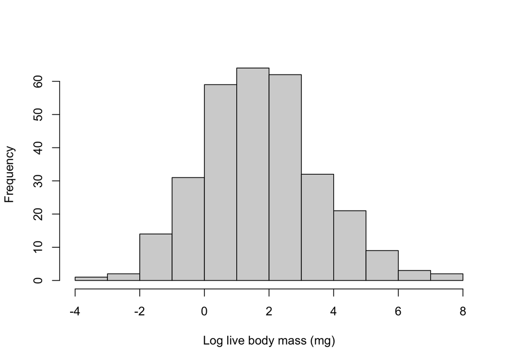

```r
# Log transform data
bugs$log_bodymass <- log(bugs$Live.body.mass..mg.)

# Test normality of log transformed data
hist(bugs$log_bodymass, main = "", xlab = "Log live body mass (mg)")
```

```r
# Shapiro test of log transformed data
shapiro.test(bugs$log_bodymass) # normal
```

```
##
##  Shapiro-Wilk normality test
##
## data:  bugs$log_bodymass
## W = 0.99408, p-value = 0.2924
```

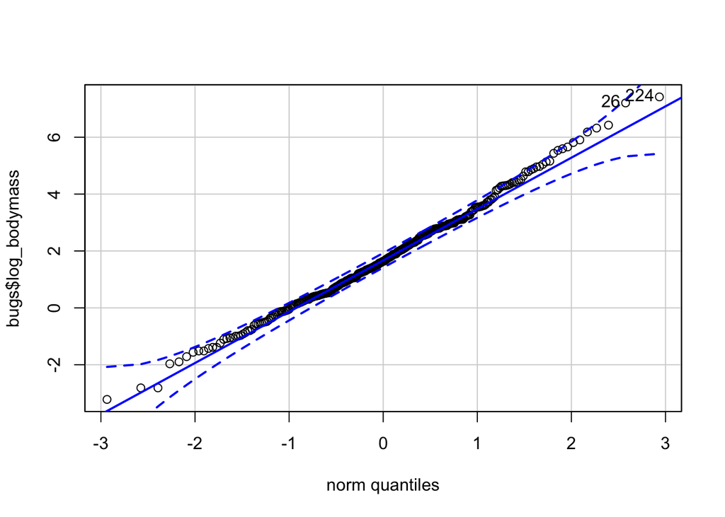

```
## [1] 224  26
```

```r
# qqPlot
qqPlot(bugs$log_bodymass)# Appears normal
```

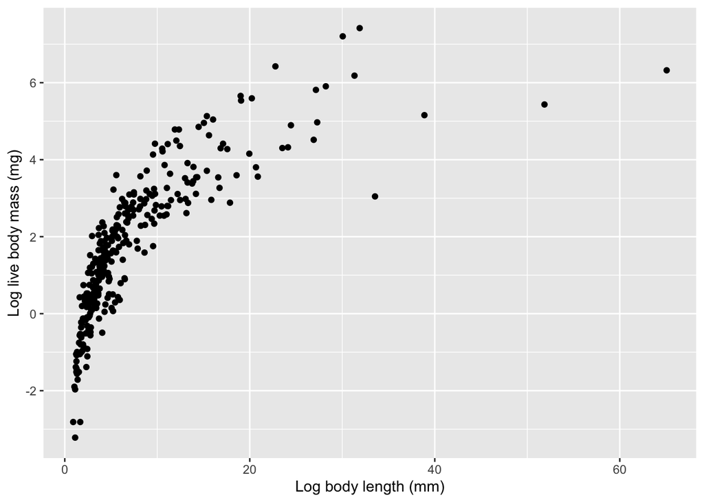

```r
# y ~ x (numeric) --> body mass and length
ggplot(bugs, aes(x = Body.length..mm., y = log_bodymass)) +
         geom_point() +
  labs(x = "Log body length (mm)", y = "Log live body mass (mg)")
```

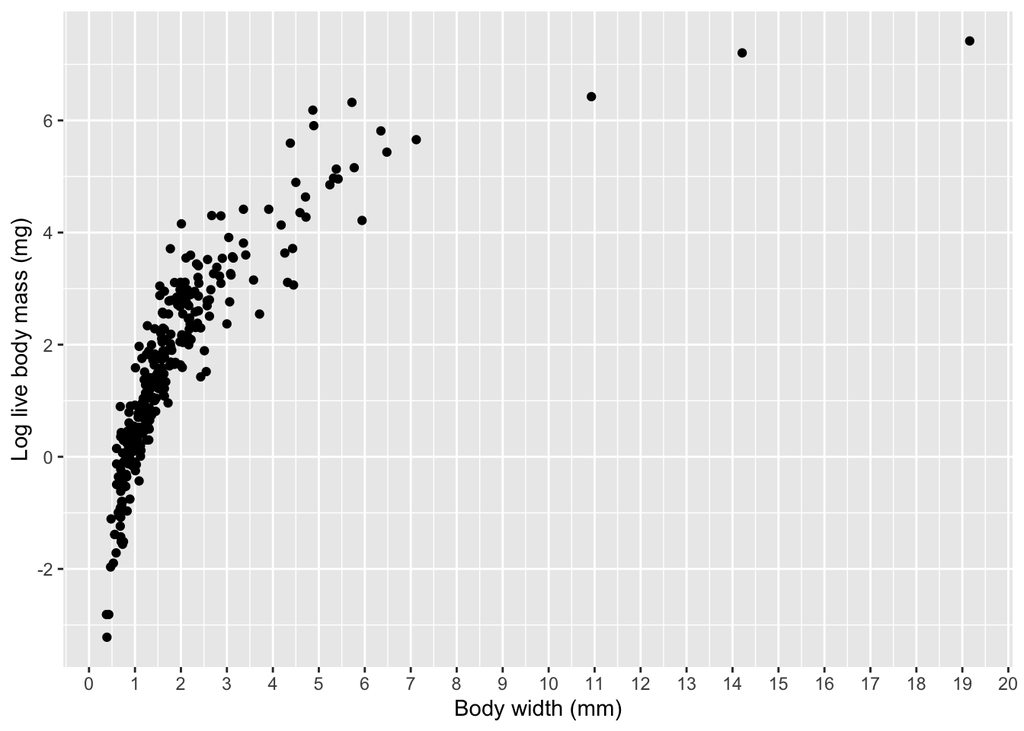

```r
# y ~ x (numeric) --> body mass and width
ggplot(bugs, aes(x = Body.width..mm., y = log_bodymass)) +
  geom_point() +
  scale_x_continuous(breaks = seq(0, 20, by = 1))  +
  labs(x = "Body width (mm)", y = "Log live body mass (mg)")
```

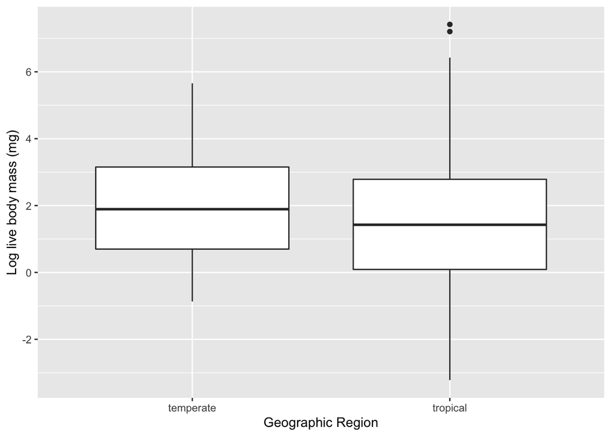

```r
# 1 graph for y ~ x (1st categorical)
ggplot(bugs, aes(x = Geographic.Region, y = log_bodymass)) +
        geom_boxplot() +
  labs(x = "Geographic Region", y = "Log live body mass (mg)")
```

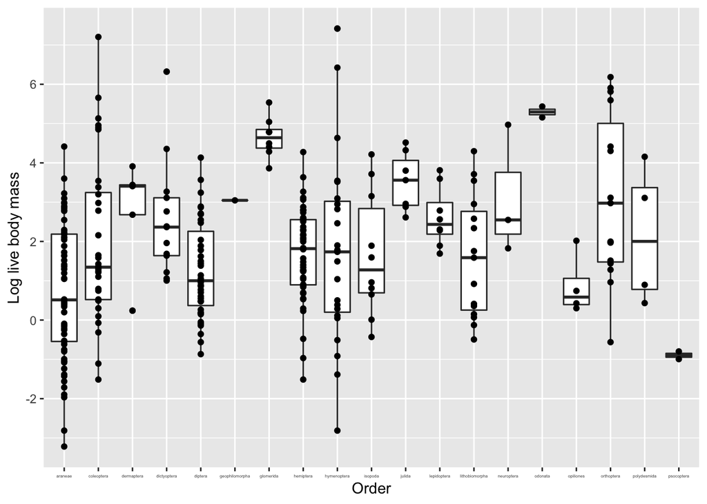

```r
# 1 graph for y ~ x (2nd categorical) --> Order
ggplot(bugs, aes(x = Order, y = log_bodymass)) + geom_boxplot() + geom_point() +  theme(axis.text.x = element_text(size = 3)) + labs(y = "Log live body mass")
```

```r
# Findings
# Non of the numeric data is normal (live body mass, body length, or body width)
# I tried transforming this data using a log transformation: This made the live body mass variable normal. The qqPlot and Shapiro Wilk test confirms this assumption of normality.

# Both the body length and body width appear correlated with the log live body mass (run a linear model to see what is best predictor)

# For the order by live body mass boxplot: I will subset data to include orders with at least 10 observations (A total of 9 Orders)
```

#### Statistical Methods

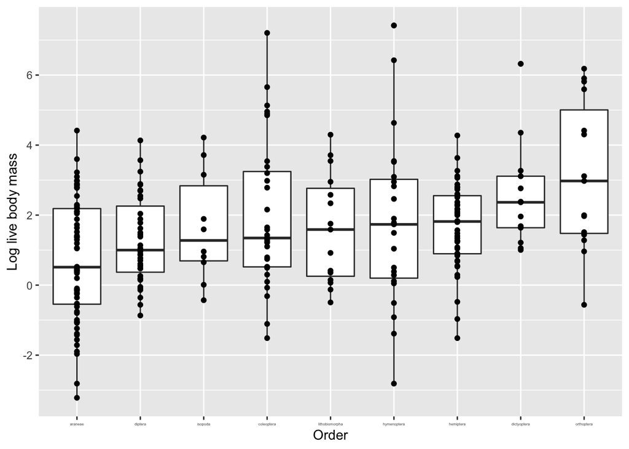

```r
# Subset order data
bugs2 <- bugs[which(bugs$Order == "coleoptera" | bugs$Order == "araneae" | bugs$Order == "dictyoptera" | bugs$Order == "dictyoptera" | bugs$Order == "diptera" | bugs$Order == "hemiptera" | bugs$Order == "hymenoptera" | bugs$Order == "isopoda" | bugs$Order == "lithobiomorpha" | bugs$Order == "orthoptera"),]

# View subsetted data
# Reorder
bugs2$Order <- factor(bugs2$Order, levels = c('araneae', 'diptera', 'isopoda','coleoptera', 'lithobiomorpha', 'hymenoptera','hemiptera', 'dictyoptera', 'orthoptera'))
ggplot(bugs2, aes(x = Order, y = log(Live.body.mass..mg.))) + geom_boxplot() + geom_point() +  theme(axis.text.x = element_text(size = 3)) + labs(y = "Log live body mass")
```

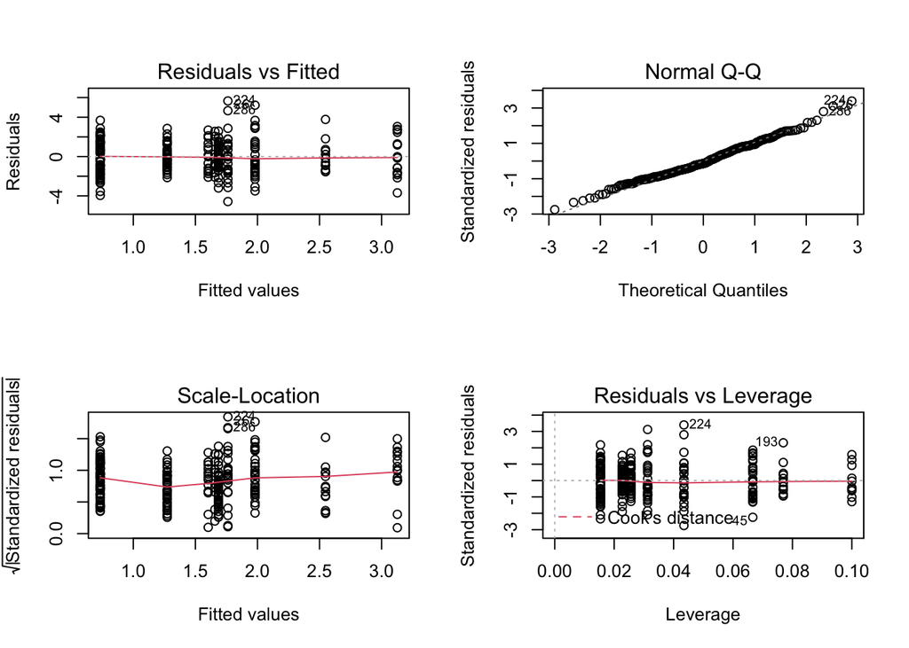

```r
# Test Anova assumptions

# Change order to factor
bugs$Order <- as.factor(bugs$Order)

# Run anova
bugs2$log_bodymass <- log(bugs2$Live.body.mass..mg.)
bugs_anova <- aov(log_bodymass ~ Order, data = bugs2)
# Create plots
par(mfrow = c(2,2))
plot(bugs_anova)
```

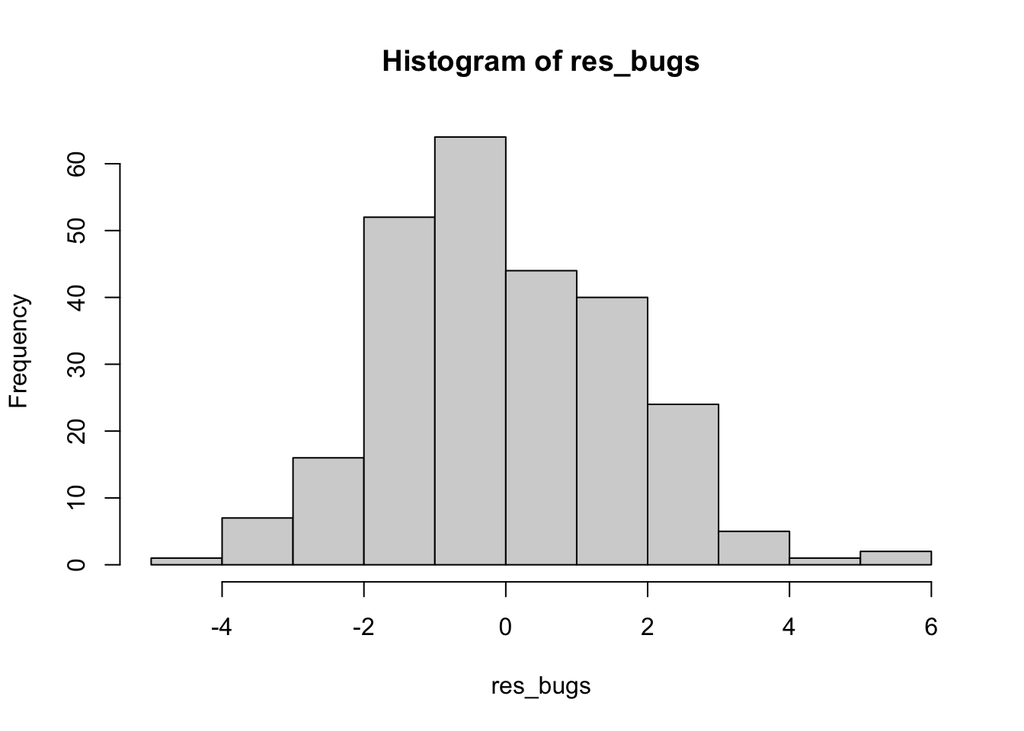

```r
par(mfrow = c(1,1)) # reset output

# Get residuals
res_bugs <- bugs_anova$residuals

# Check normality
hist(res_bugs) # Normal
```

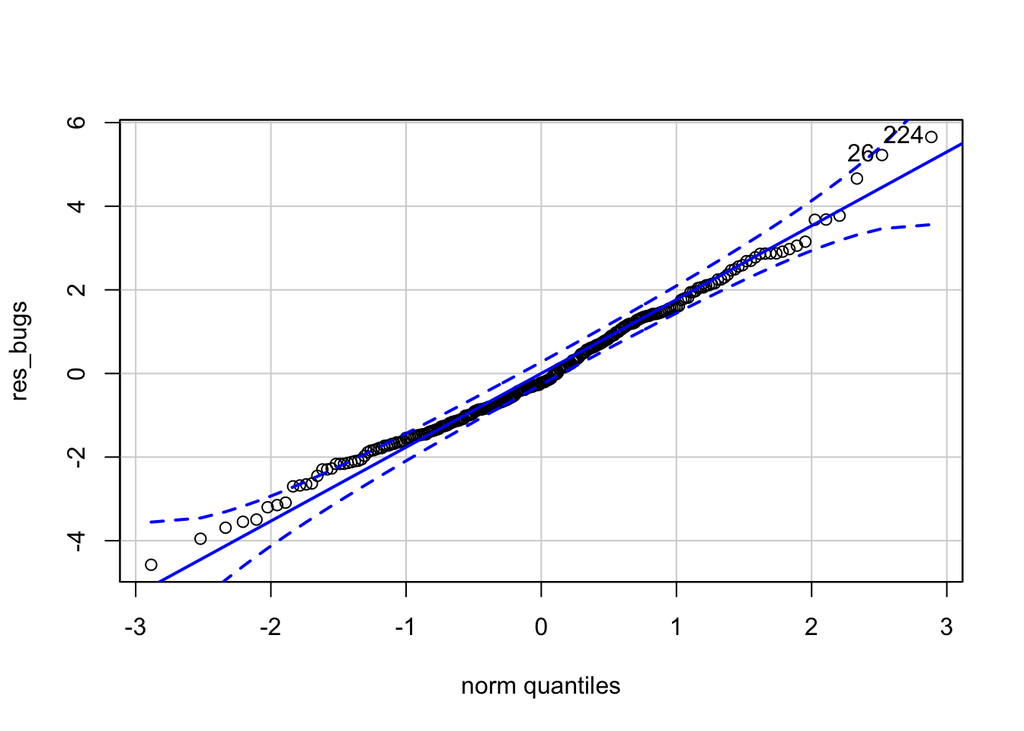

```
## 224  26
## 191  25
```

```r
qqPlot(res_bugs) # Normal
```

```r
shapiro.test(res_bugs) # Normal
```

```
##
##  Shapiro-Wilk normality test
##
## data:  res_bugs
## W = 0.98971, p-value = 0.06644
```

```r
# Check variance
leveneTest(log_bodymass ~ Order, bugs2) # Does not have equal variance
```

```
## Levene's Test for Homogeneity of Variance (center = median)
##        Df F value  Pr(>F)
## group   8  2.7497 0.00633 **
##       247
## ---
## Signif. codes:  0 '***' 0.001 '**' 0.01 '*' 0.05 '.' 0.1 ' ' 1
```

```r
# Try new transformation
bugs2$sqrt_livebodymass <- sqrt(bugs2$Live.body.mass..mg.)

leveneTest(sqrt_livebodymass ~ Order, bugs2) # Does not have equal variance
```

```
## Levene's Test for Homogeneity of Variance (center = median)
##        Df F value    Pr(>F)
## group   8  3.5924 0.0005764 ***
##       247
## ---
## Signif. codes:  0 '***' 0.001 '**' 0.01 '*' 0.05 '.' 0.1 ' ' 1
```

```r
# Run a non parametric test: Kruskal test
bugs_kruskal <- kruskal.test(Live.body.mass..mg. ~ Order, data = bugs2)

# Dunn Test - non parametric post hoc analysis
bugs_dunn <- dunnTest(Live.body.mass..mg. ~ Order, data = bugs2, method = "bonferroni", list = TRUE)

# Display data in table
# Set column values of significant comparisons
comparison <- c("Araneae - dictyoptera", "Araneae-orthoptera")
Z <- c(-3.31, -3.95)
P.unadj <- c(9.17e-04, 7.78e-05)
P.adj <- c(0.033, 0.0028)

Bugs_dunn_data <- data.frame(comparison, Z, P.unadj, P.adj)
kable(Bugs_dunn_data, col.names = c("Comparison", "Z", "P-value: unadjusted", "P-value: adjusted"))
```

| Comparison | Z | P-value: unadjusted | P-value: adjusted |
| --- | --- | --- | --- |
| Araneae - dictyoptera | -3.31 | 9.17e-04 | 0.0330 |
| Araneae-orthoptera | -3.95 | 7.78e-05 | 0.0028 |

```r
# Results: there is a significant difference between Araneae and Dictyoptera and Araneae and Orthoptera
```

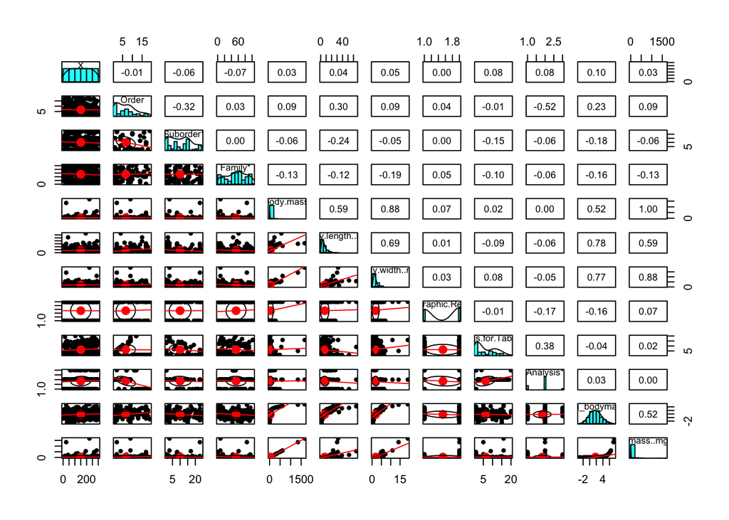

```r
# Linear model to find best predictor

# test assumptions:
pairs.panels(bugs, lm = TRUE, cor = T)
```

```r
# Random sample
# Colinearity --> take out body width or length
# Linear relationship between predictors and response ?? (Ask)
# Residuals are normal and have equal variance

bodylength_lm <- lm(log_bodymass ~ Body.length..mm., data = bugs)
bodywidth_lm <- lm(log_bodymass ~ Body.width..mm., data = bugs)
order_lm <- lm(log_bodymass ~ Order, data = bugs)
geography_lm <- lm(log_bodymass ~ Geographic.Region, data = bugs)
bugs_lm1 <- lm(log_bodymass ~ Body.length..mm. + Order, data = bugs)
bugs_lm2 <- lm(log_bodymass ~ Body.length..mm. + Order + Geographic.Region, data = bugs)

# Check normality of residuals
res_bodylength_lm <- bodylength_lm$residuals
res_bodywidth_lm <- bodywidth_lm$residuals
res_order_lm <- order_lm$residuals
res_geography_lm <- geography_lm$residuals
res_bugs_lm1 <- bugs_lm1$residuals
res_bugs_lm2 <- bugs_lm2$residuals

shapiro.test(res_bodylength_lm) # Not normal
```

```
##
##  Shapiro-Wilk normality test
##
## data:  res_bodylength_lm
## W = 0.94566, p-value = 4.5e-09
```

```r
shapiro.test(res_bodywidth_lm ) # Not normal
```

```
##
##  Shapiro-Wilk normality test
##
## data:  res_bodywidth_lm
## W = 0.9345, p-value = 6.58e-10
```

```r
shapiro.test(res_order_lm) # normal
```

```
##
##  Shapiro-Wilk normality test
##
## data:  res_order_lm
## W = 0.9909, p-value = 0.06002
```

```r
shapiro.test(res_geography_lm) # Not normal
```

```
##
##  Shapiro-Wilk normality test
##
## data:  res_geography_lm
## W = 0.98904, p-value = 0.02324
```

```r
shapiro.test(res_bugs_lm1) # Not normal
```

```
##
##  Shapiro-Wilk normality test
##
## data:  res_bugs_lm1
## W = 0.91339, p-value = 3.88e-12
```

```r
shapiro.test(res_bugs_lm2) # Not normal
```

```
##
##  Shapiro-Wilk normality test
##
## data:  res_bugs_lm2
## W = 0.91091, p-value = 2.436e-12
```

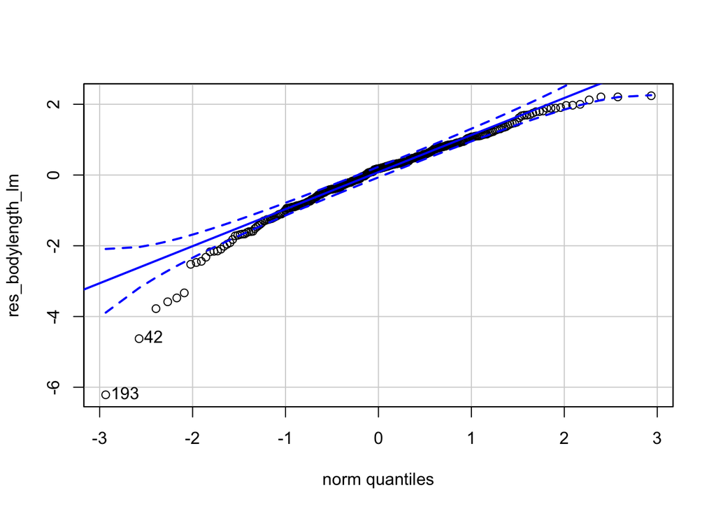

```
## [1] 193  42
```

```r
qqPlot(res_bodylength_lm) # Not normal
```

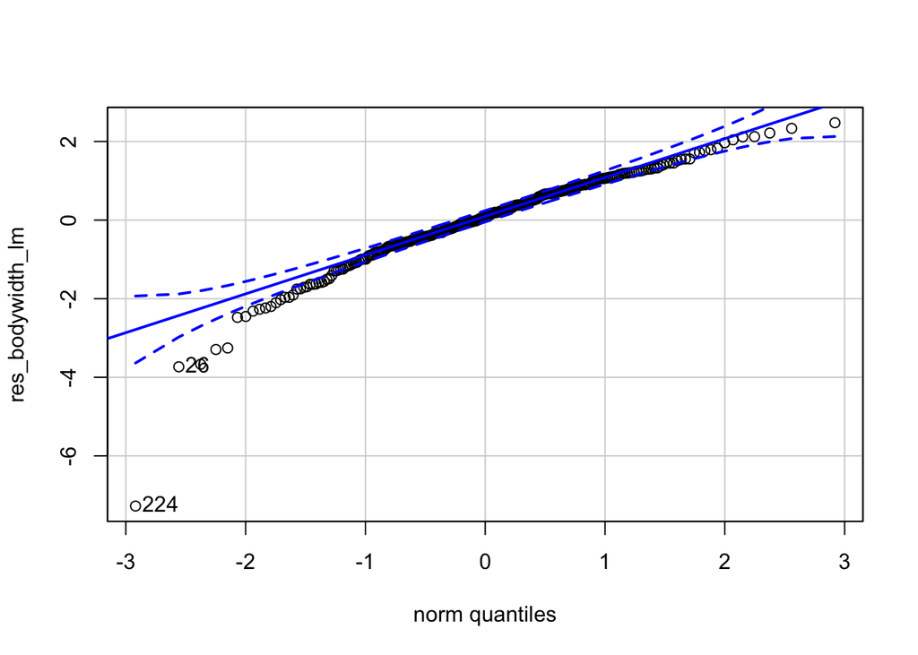

```
## 224  26
## 213  26
```

```r
qqPlot(res_bodywidth_lm ) # Not normal
```

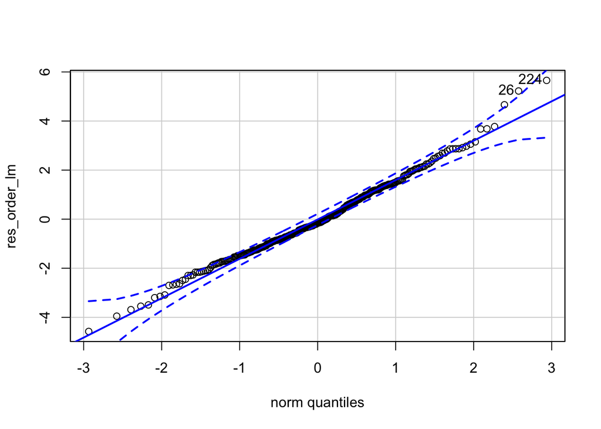

```
## [1] 224  26
```

```r
qqPlot(res_order_lm) # normal
```

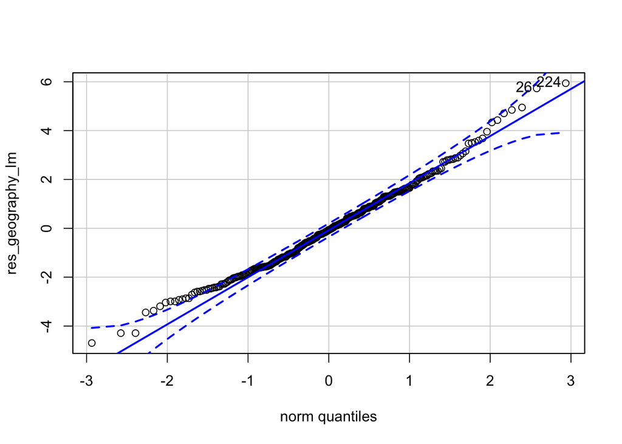

```
## [1] 224  26
```

```r
qqPlot(res_geography_lm) # Not normal
```

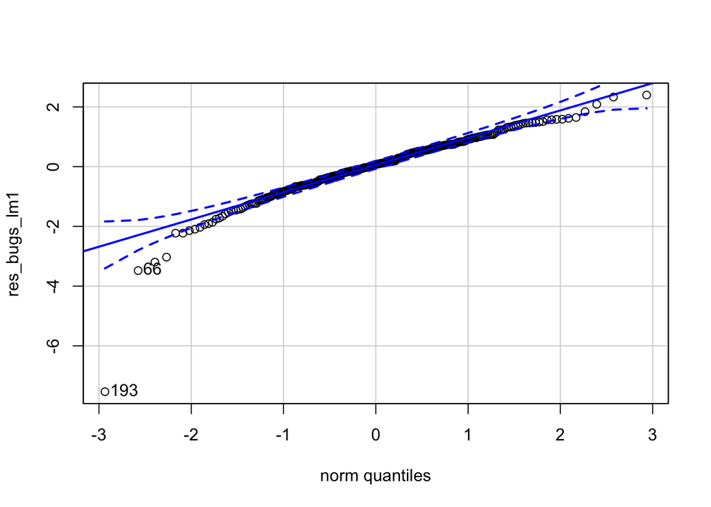

```
## [1] 193  66
```

```r
qqPlot(res_bugs_lm1) # Not normal
```

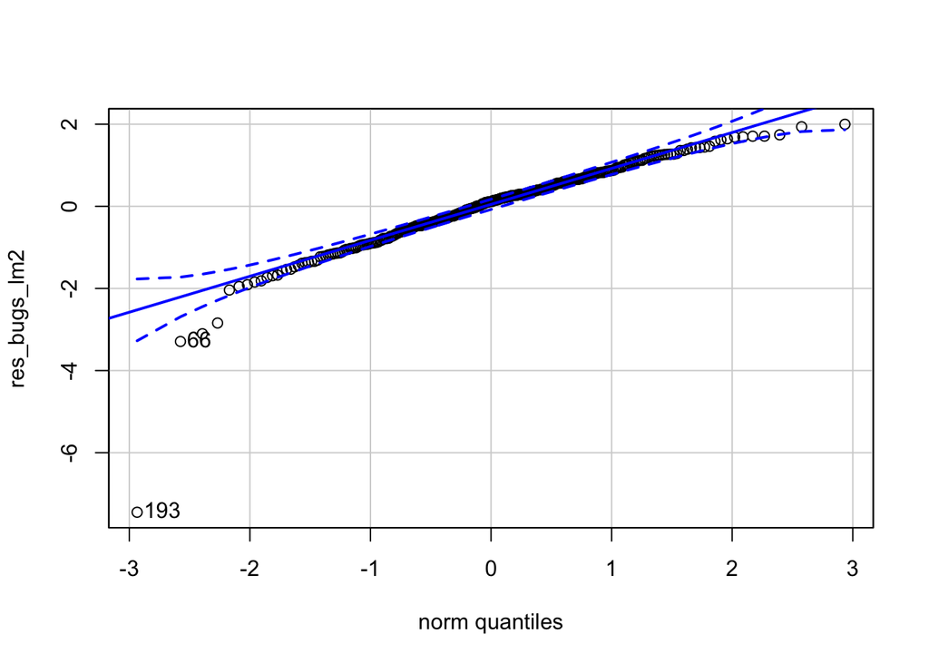

```
## [1] 193  66
```

```r
qqPlot(res_bugs_lm2) # Not normal
```

```r
# Try transforming x variable
bodylength_lm2 <- lm(log_bodymass ~ log(Body.length..mm.), data = bugs)
bodywidth_lm2 <- lm(log_bodymass ~ log(Body.width..mm.), data = bugs)
order_lm2 <- lm(log_bodymass ~ Order, data = bugs)
geography_lm2 <- lm(log_bodymass ~ Geographic.Region, data = bugs)
bugs_lm12 <- lm(log_bodymass ~ log(Body.length..mm.) + Order, data = bugs)
bugs_lm22 <- lm(log_bodymass ~ log(Body.length..mm.) + Order + Geographic.Region, data = bugs)

# Check normality again
res_bodylength_lm2 <- bodylength_lm2$residuals
res_bodywidth_lm2 <- bodywidth_lm2$residuals
res_order_lm2 <- order_lm2$residuals
res_geography_lm2 <- geography_lm2$residuals
res_bugs_lm12 <- bugs_lm12$residuals
res_bugs_lm22 <- bugs_lm22$residuals

shapiro.test(res_bodylength_lm2) # normal
```

```
##
##  Shapiro-Wilk normality test
##
## data:  res_bodylength_lm2
## W = 0.99248, p-value = 0.1344
```

```r
shapiro.test(res_bodywidth_lm2 ) # normal
```

```
##
##  Shapiro-Wilk normality test
##
## data:  res_bodywidth_lm2
## W = 0.99182, p-value = 0.1163
```

```r
shapiro.test(res_order_lm2) # normal
```

```
##
##  Shapiro-Wilk normality test
##
## data:  res_order_lm2
## W = 0.9909, p-value = 0.06002
```

```r
shapiro.test(res_geography_lm2) # Not normal
```

```
##
##  Shapiro-Wilk normality test
##
## data:  res_geography_lm2
## W = 0.98904, p-value = 0.02324
```

```r
shapiro.test(res_bugs_lm12) # Not normal
```

```
##
##  Shapiro-Wilk normality test
##
## data:  res_bugs_lm12
## W = 0.98298, p-value = 0.00125
```

```r
shapiro.test(res_bugs_lm22) # Not normal
```

```
##
##  Shapiro-Wilk normality test
##
## data:  res_bugs_lm22
## W = 0.97284, p-value = 1.886e-05
```

```r
# The data do not meet assumptions: geographic region/order are not linear with response variable and the residuals are not normal. I will instead use a general linear model using Poisson as the family


# Round data to use a poisson
bugs$Live.body.mass..mg._rounded <- round(bugs$Live.body.mass..mg.)

# Make GlM's
bodylength_glm <- glm(Live.body.mass..mg._rounded ~ Body.length..mm., data = bugs, family = "poisson")
bodywidth_glm <- glm(Live.body.mass..mg._rounded ~ Body.width..mm., data = bugs, family = "poisson")
length_width_int <- glm(Live.body.mass..mg._rounded ~ Body.width..mm. * Body.length..mm., data = bugs, family = "poisson")
length_width <- glm(Live.body.mass..mg._rounded ~ Body.width..mm. + Body.length..mm., data = bugs, family = "poisson")

# Width is a stronger predictor than length, there is an interaction between length and width

# Check other variables
order_glm <- glm(Live.body.mass..mg._rounded ~ Order, data = bugs, family = "poisson")
geography_glm <- glm(Live.body.mass..mg._rounded ~ Geographic.Region, data = bugs, family = "poisson")

# Not as strong

# Combinations
bodylength_width_int_order <- glm(Live.body.mass..mg._rounded ~ Body.length..mm. * Body.width..mm. + Order, data = bugs, family = "poisson")
bodylength_width_int_geography <- glm(Live.body.mass..mg._rounded ~ Body.length..mm. * Body.width..mm. + Geographic.Region, data = bugs, family = "poisson")
full_glm <- glm(Live.body.mass..mg._rounded ~ Body.length..mm. * Body.width..mm. + Order + Geographic.Region, data = bugs, family = "poisson")


# Calculate AIC of each model
result <- AIC(bodylength_glm, bodywidth_glm, length_width_int, length_width, order_glm, geography_glm, bodylength_width_int_order, bodylength_width_int_geography, full_glm)

# Add other metrics
models <- list(bodylength_glm, bodywidth_glm, length_width_int, length_width, order_glm, geography_glm, bodylength_width_int_order, bodylength_width_int_geography, full_glm)
result$BIC <- sapply(models, BIC)

model_summary <- lapply(models, summary)

# Get R squared and add to table
for(i in 1:length(models)){
  result$rsq[i] <- model_summary[[i]]$r.squared
  result$adj_rsq[i] <- model_summary[[i]]$adj.r.squared}


kable(result, digits = 2, align = "c")
```

|  | df | AIC | BIC |
| --- | --- | --- | --- |
| bodylength_glm | 2 | 21391.51 | 21398.92 |
| bodywidth_glm | 2 | 12465.65 | 12472.96 |
| length_width_int | 4 | 2877.34 | 2891.95 |
| length_width | 3 | 7192.92 | 7203.87 |
| order_glm | 19 | 28697.96 | 28768.33 |
| geography_glm | 2 | 40232.32 | 40239.73 |
| bodylength_width_int_order | 20 | 1688.81 | 1761.86 |
| bodylength_width_int_geography | 5 | 2807.78 | 2826.04 |
| full_glm | 21 | 1635.01 | 1711.72 |

```r
bugs_updated <- bugs
write.csv(bugs_updated, file = 'bugs_updated.csv')
# There is an interaction between body length and body width
# Best model: uses all factors with an interaction of body length and width
```